# DATA 607 Final Project

Brad Harbans

5/16/2021

## Introduction

Citi Bike is the nation’s largest bike share program, with 20,000 bikes and over 1,300 stations across Manhattan, Brooklyn, Queens, the Bronx and Jersey City. All trip data is publicly available. For the purposed of this assignment I will be using the BigQuery Public data set to explore the data. (Motivate International, n.d.)

## Import BigQuery Data

First I will import the general trip information.

```r
sampleTripsQuery <- "SELECT
                      *,
                      CONCAT(start_station_name, \" to \", end_station_name) as route,
                      EXTRACT(DAYOFWEEK from starttime) as startday,
                      EXTRACT(MONTH from starttime) as startmonth,
                      EXTRACT(YEAR from starttime) as startyear,
                      (EXTRACT(YEAR from starttime) - birth_year) as age
                    FROM
                      `bigquery-public-data.new_york.citibike_trips`
                    WHERE ABS(MOD(FARM_FINGERPRINT(CAST(starttime AS string )), 10)) < 2"


sampleTripsBQTable <- bq_project_query (projectid, sampleTripsQuery )
sampleTrips <- bq_table_download(sampleTripsBQTable, page_size = 100000)
```

I will now import zip code information based on a spatial join with the `data.geo_us_boundaries.zip_codes` public dataset.

```r
allStationsWithZipQuery <- "SELECT
    *
FROM
    `bigquery-public-data.new_york.citibike_stations` AS bike_stations,
    `bigquery-public-data.geo_us_boundaries.zip_codes` AS zip_codes
WHERE ST_Within(
        ST_GeogPoint(bike_stations.longitude, bike_stations.latitude),
         zip_codes.zip_code_geom
         )
"

allStationsWithZipQTable <- bq_project_query (projectid, allStationsWithZipQuery )
allStationsWithZip <- bq_table_download(allStationsWithZipQTable, page_size = 100000)
```

### Use Census Data Instead of Zip Codes

It was easier to use the US census data to obtain demographic information about the stations. (Petti 2020)

```r
allStationsCensusDataQuery <- "SELECT * FROM
(SELECT *
  EXCEPT (internal_point_geo, tract_geom)
FROM `bigquery-public-data.new_york_citibike.citibike_stations` AS bike_stations,
  `bigquery-public-data.geo_census_tracts.us_census_tracts_national` AS us_census_tracts_national
WHERE ST_Within(
        ST_GeogPoint(bike_stations.longitude, bike_stations.latitude),
        us_census_tracts_national.tract_geom)
) AS table1, `bigquery-public-data.census_bureau_acs.censustract_2018_5yr` as ctract
WHERE table1.geo_id = ctract.geo_id"

allStationsCensusDataQTable <- bq_project_query (projectid, allStationsCensusDataQuery )
allStationsCensusData <- bq_table_download(allStationsCensusDataQTable, page_size = 100000)
```

### Obtaining Neighborhood data from CSV

Using the NYC Neighborhoods data set, I am able to obtain the neigborhood names from the zip codes. (datHere 2020).

```r
zipCodeInfo<-read.csv("https://data.beta.nyc/dataset/0ff93d2d-90ba-457c-9f7e-39e47bf2ac5f/resource/7caac650-d082-4aea-9f9b-3681d568e8a5/download/nyc_zip_borough_neighborhoods_pop.csv") %>%
  mutate(zip = as.character(zip)) %>%
  select( zip, borough, neighborhood)
```

### Examining Raw Data

```r
dim(sampleTrips )
```

```
## [1] 6662911      20
```

```r
sampleTrips %>%
  head(20) %>%
  reactable(wrap = F)
```

| tripduration | starttime | stoptime | start_station_id | start_station_name | start_station_latitude | start_station_longitude | end_station_id | end_station_name | end_station_latitude | end_station_longitude | bikeid | usertype | birth_year | gender | route | startday | startmonth | startyear | age |
| --- | --- | --- | --- | --- | --- | --- | --- | --- | --- | --- | --- | --- | --- | --- | --- | --- | --- | --- | --- |
| 295 | 2016-09-10T19:08:35 | 2016-09-10T19:13:31 | 529 | W 42 St & 8 Ave | 40.7575699 | -73.99098507 | 478 | 11 Ave & W 41 St | 40.76030096 | -73.99884222 | 20937 | Subscriber | 1989 | female | W 42 St & 8 Ave to 11 Ave & W 41 St | 7 | 9 | 2016 | 27 |
| 183 | 2016-05-13T14:07:47 | 2016-05-13T14:10:51 | 525 | W 34 St & 11 Ave | 40.75594159 | -74.0021163 | 478 | 11 Ave & W 41 St | 40.76030096 | -73.99884222 | 22130 | Subscriber | 1988 | male | W 34 St & 11 Ave to 11 Ave & W 41 St | 6 | 5 | 2016 | 28 |
| 541 | 2014-08-15T17:27:55 | 2014-08-15T17:36:56 | 490 | 8 Ave & W 33 St | 40.751551 | -73.993934 | 478 | 11 Ave & W 41 St | 40.76030096 | -73.99884222 | 19110 | Subscriber | 1991 | male | 8 Ave & W 33 St to 11 Ave & W 41 St | 6 | 8 | 2014 | 23 |
| 368 | 2015-10-23T23:29:34 | 2015-10-23T23:35:42 | 490 | 8 Ave & W 33 St | 40.751551 | -73.993934 | 478 | 11 Ave & W 41 St | 40.76030096 | -73.99884222 | 23686 | Subscriber | 1971 | male | 8 Ave & W 33 St to 11 Ave & W 41 St | 6 | 10 | 2015 | 44 |
| 935 | 2014-12-31T13:25:46 | 2014-12-31T13:41:21 | 116 | W 17 St & 8 Ave | 40.74177603 | -74.00149746 | 478 | 11 Ave & W 41 St | 40.76030096 | -73.99884222 | 15242 | Subscriber | 1985 | male | W 17 St & 8 Ave to 11 Ave & W 41 St | 4 | 12 | 2014 | 29 |
| 136 | 2014-01-21T07:25:38 | 2014-01-21T07:27:54 | 448 | W 37 St & 10 Ave | 40.75660359 | -73.9979009 | 478 | 11 Ave & W 41 St | 40.76030096 | -73.99884222 | 14580 | Subscriber | 1974 | male | W 37 St & 10 Ave to 11 Ave & W 41 St | 3 | 1 | 2014 | 40 |
| 1689 | 2014-02-23T11:18:01 | 2014-02-23T11:46:10 | 426 | West St & Chambers St | 40.71754834 | -74.01322069 | 478 | 11 Ave & W 41 St | 40.76030096 | -73.99884222 | 18443 | Subscriber | 1978 | female | West St & Chambers St to 11 Ave & W 41 St | 1 | 2 | 2014 | 36 |
| 312 | 2015-07-22T18:28:47 | 2015-07-22T18:34:00 | 523 | W 38 St & 8 Ave | 40.75466591 | -73.99138152 | 478 | 11 Ave & W 41 St | 40.76030096 | -73.99884222 | 15034 | Subscriber | 1981 | male | W 38 St & 8 Ave to 11 Ave & W 41 St | 4 | 7 | 2015 | 34 |
| 738 | 2014-05-05T18:58:06 | 2014-05-05T19:10:24 | 499 | Broadway & W 60 St | 40.76915505 | -73.98191841 | 478 | 11 Ave & W 41 St | 40.76030096 | -73.99884222 | 18064 | Subscriber | 1987 | male | Broadway & W 60 St to 11 Ave & W 41 St | 2 | 5 | 2014 | 27 |
| 1779 | 2014-10-09T16:23:29 | 2014-10-09T16:53:08 | 348 | W Broadway & Spring St | 40.72490985 | -74.00154702 | 478 | 11 Ave & W 41 St | 40.76030096 | -73.99884222 | 18943 | Subscriber | 1979 | male | W Broadway & Spring St to 11 Ave & W 41 St | 5 | 10 | 2014 | 35 |

[output cut: 10 more lines]

```r
allStationsCensusData %>%
  head(20) %>%
  reactable(wrap=F)
```

| station_id | name | short_name | latitude | longitude | region_id | rental_methods | capacity | eightd_has_key_dispenser | num_bikes_available | num_bikes_disabled | num_docks_available | num_docks_disabled | is_installed | is_renting | is_returning | eightd_has_available_keys | last_reported | state_name | state_fips_code | county_fips_code | tract_ce | geo_id | tract_name | lsad_name | functional_status | area_land_meters | area_water_meters | internal_point_lat | internal_point_lon | … |
| --- | --- | --- | --- | --- | --- | --- | --- | --- | --- | --- | --- | --- | --- | --- | --- | --- | --- | --- | --- | --- | --- | --- | --- | --- | --- | --- | --- | --- | --- | --- |
| 456 | E 53 St & Madison Ave | 6659.03 | 40.7597108 | -73.97402311 | 71 | KEY,CREDITCARD | 34 | False | 13 | 0 | 21 | 0 | True | True | True | False | 2020-04-14T00:00:00 | New York | 36 | 061 | 010200 | 36061010200 | 102 | Census Tract 102 | S | 172891 | 0 | +40.7594238 | -073.9744493 | … |
| 3221 | 47 Ave & 31 St | 6151.03 | 40.743 | -73.93561 | 71 | KEY,CREDITCARD | 27 | False | 19 | 0 | 8 | 0 | True | True | True | False | 2020-04-15T00:00:00 | New York | 36 | 081 | 019900 | 36081019900 | 199 | Census Tract 199 | S | 1590839 | 87694 | +40.7331325 | -073.9304349 | … |
| 3647 | 48 Ave & 30 Pl | 6076.01 | 40.7412830935599 | -73.9372587203979 | 71 | KEY,CREDITCARD | 23 | False | 17 | 0 | 6 | 0 | True | True | True | False | 2020-04-14T00:00:00 | New York | 36 | 081 | 019900 | 36081019900 | 199 | Census Tract 199 | S | 1590839 | 87694 | +40.7331325 | -073.9304349 | … |
| 3824 | Van Sinderen Ave & Truxton St | 4161.01 | 40.6786 | -73.90369 | 71 | KEY,CREDITCARD | 23 | False | 16 | 0 | 7 | 0 | True | True | True | False | 2020-04-14T00:00:00 | New York | 36 | 047 | 036700 | 36047036700 | 367 | Census Tract 367 | S | 182968 | 0 | +40.6775646 | -073.9046130 | … |
| 3867 | Somers St & Broadway | 4203.04 | 40.67945 | -73.90474 | 71 | KEY,CREDITCARD | 29 | False | 3 | 0 | 26 | 0 | True | True | True | False | 2020-04-14T00:00:00 | New York | 36 | 047 | 036700 | 36047036700 | 367 | Census Tract 367 | S | 182968 | 0 | +40.6775646 | -073.9046130 | … |
| 3609 | Vernon Blvd & 31 Ave | 7003.06 | 40.7692475 | -73.9354504 | 71 | KEY,CREDITCARD | 23 | False | 22 | 1 | 0 | 0 | True | True | True | False | 2020-04-14T00:00:00 | New York | 36 | 081 | 008100 | 36081008100 | 81 | Census Tract 81 | S | 112317 | 0 | +40.7700756 | -073.9335826 | … |
| 3610 | Vernon Blvd & 30 Rd | 7003.03 | 40.770845 | -73.934171 | 71 | KEY,CREDITCARD | 27 | True | 11 | 0 | 16 | 0 | True | True | True | True | 2020-04-14T00:00:00 | New York | 36 | 081 | 008100 | 36081008100 | 81 | Census Tract 81 | S | 112317 | 0 | +40.7700756 | -073.9335826 | … |
| 3833 | Madison St & Evergreen Ave | 4560.01 | 40.69122 | -73.91693 | 71 | KEY,CREDITCARD | 18 | False | 13 | 0 | 5 | 0 | True | True | True | False | 2020-04-14T00:00:00 | New York | 36 | 047 | 041500 | 36047041500 | 415 | Census Tract 415 | S | 162692 | 0 | +40.6919502 | -073.9143896 | … |
| 3903 | Jefferson Ave & Evergreen Ave | 4517.03 | 40.68989 | -73.91458 | 71 | KEY,CREDITCARD | 17 | False | 12 | 0 | 5 | 0 | True | True | True | False | 2020-04-14T00:00:00 | New York | 36 | 047 | 041500 | 36047041500 | 415 | Census Tract 415 | S | 162692 | 0 | +40.6919502 | -073.9143896 | … |
| 3863 | Central Ave & Woodbine St | 4632.10 | 40.69296 | -73.91605 | 71 | KEY,CREDITCARD | 18 | False | 12 | 0 | 6 | 0 | True | True | True | False | 2020-04-14T00:00:00 | New York | 36 | 047 | 041500 | 36047041500 | 415 | Census Tract 415 | S | 162692 | 0 | +40.6919502 | -073.9143896 | … |

[output cut: 10 more lines]

```r
zipCodeInfo %>%
  reactable(wrap=T)
```

| zip | borough | neighborhood |
| --- | --- | --- |
| 10001 | Manhattan | Chelsea and Clinton |
| 10002 | Manhattan | Lower East Side |
| 10003 | Manhattan | Lower East Side |
| 10004 | Manhattan | Lower Manhattan |
| 10005 | Manhattan | Lower Manhattan |
| 10006 | Manhattan | Lower Manhattan |
| 10007 | Manhattan | Lower Manhattan |
| 10009 | Manhattan | Lower East Side |
| 10010 | Manhattan | Gramercy Park and Murray Hill |
| 10011 | Manhattan | Chelsea and Clinton |

[output cut: 167 more lines]

### Combine Data

```r
allStationsWithZip <- allStationsWithZip %>%
  select( -ends_with("_geom")) %>%
  right_join(zipCodeInfo,by = c("zip_code"="zip")) %>%
  select( station_id,zip_code, borough ,neighborhood )
```

```r
allStationData <-
  allStationsCensusData %>%
  left_join(allStationsWithZip, by = c("station_id"="station_id"))
```

```r
sample <- sampleTrips %>%
  select( tripduration , start_station_id, start_station_name , end_station_id,
          end_station_name, usertype, birth_year, gender, route, startday,
          startmonth, startyear , age) %>%
  left_join(allStationData, by = c("start_station_id"="station_id") )
```

### Final Data Raw

```r
sample %>%
  head(100) %>%
  reactable(wrap=F)
```

| tripduration | start_station_id | start_station_name | end_station_id | end_station_name | usertype | birth_year | gender | route | startday | startmonth | startyear | age | name | short_name | latitude | longitude | region_id | rental_methods | capacity | eightd_has_key_dispenser | num_bikes_available | num_bikes_disabled | num_docks_available | num_docks_disabled | is_installed | is_renting | is_returning | eightd_has_available_keys | last_reported | … |
| --- | --- | --- | --- | --- | --- | --- | --- | --- | --- | --- | --- | --- | --- | --- | --- | --- | --- | --- | --- | --- | --- | --- | --- | --- | --- | --- | --- | --- | --- | --- |
| 295 | 529 | W 42 St & 8 Ave | 478 | 11 Ave & W 41 St | Subscriber | 1989 | female | W 42 St & 8 Ave to 11 Ave & W 41 St | 7 | 9 | 2016 | 27 | W 42 St & 8 Ave | 6602.05 | 40.7575699 | -73.99098507 | 71 | KEY,CREDITCARD | 41 | False | 19 | 6 | 16 | 0 | True | True | True | False | 2020-04-15T00:00:00 | … |
| 183 | 525 | W 34 St & 11 Ave | 478 | 11 Ave & W 41 St | Subscriber | 1988 | male | W 34 St & 11 Ave to 11 Ave & W 41 St | 6 | 5 | 2016 | 28 | W 34 St & 11 Ave | 6578.01 | 40.75594159 | -74.0021163 | 71 | KEY,CREDITCARD | 55 | False | 40 | 0 | 15 | 0 | True | True | True | False | 2020-04-15T00:00:00 | … |
| 541 | 490 | 8 Ave & W 33 St | 478 | 11 Ave & W 41 St | Subscriber | 1991 | male | 8 Ave & W 33 St to 11 Ave & W 41 St | 6 | 8 | 2014 | 23 | 8 Ave & W 33 St | 6450.12 | 40.751551 | -73.993934 | 71 | KEY,CREDITCARD | 66 | False | 31 | 2 | 33 | 0 | True | True | True | False | 2020-04-15T00:00:00 | … |
| 368 | 490 | 8 Ave & W 33 St | 478 | 11 Ave & W 41 St | Subscriber | 1971 | male | 8 Ave & W 33 St to 11 Ave & W 41 St | 6 | 10 | 2015 | 44 | 8 Ave & W 33 St | 6450.12 | 40.751551 | -73.993934 | 71 | KEY,CREDITCARD | 66 | False | 31 | 2 | 33 | 0 | True | True | True | False | 2020-04-15T00:00:00 | … |
| 935 | 116 | W 17 St & 8 Ave | 478 | 11 Ave & W 41 St | Subscriber | 1985 | male | W 17 St & 8 Ave to 11 Ave & W 41 St | 4 | 12 | 2014 | 29 | W 17 St & 8 Ave | 6148.02 | 40.74177603 | -74.00149746 | 71 | KEY,CREDITCARD | 50 | False | 29 | 0 | 21 | 0 | True | True | True | False | 2020-04-15T00:00:00 | … |
| 136 | 448 | W 37 St & 10 Ave | 478 | 11 Ave & W 41 St | Subscriber | 1974 | male | W 37 St & 10 Ave to 11 Ave & W 41 St | 3 | 1 | 2014 | 40 | W 37 St & 10 Ave | 6611.02 | 40.75660359 | -73.9979009 | 71 | KEY,CREDITCARD | 27 | False | 17 | 0 | 10 | 0 | True | True | True | False | 2020-04-15T00:00:00 | … |
| 1689 | 426 | West St & Chambers St | 478 | 11 Ave & W 41 St | Subscriber | 1978 | female | West St & Chambers St to 11 Ave & W 41 St | 1 | 2 | 2014 | 36 | West St & Chambers St | 5329.03 | 40.71754834 | -74.01322069 | 71 | KEY,CREDITCARD | 30 | True | 14 | 1 | 15 | 0 | True | True | True | True | 2020-04-15T00:00:00 | … |
| 312 | 523 | W 38 St & 8 Ave | 478 | 11 Ave & W 41 St | Subscriber | 1981 | male | W 38 St & 8 Ave to 11 Ave & W 41 St | 4 | 7 | 2015 | 34 | W 38 St & 8 Ave | 6526.03 | 40.75466591 | -73.99138152 | 71 | KEY,CREDITCARD | 51 | False | 5 | 1 | 45 | 0 | True | True | True | False | 2020-04-15T00:00:00 | … |
| 738 | 499 | Broadway & W 60 St | 478 | 11 Ave & W 41 St | Subscriber | 1987 | male | Broadway & W 60 St to 11 Ave & W 41 St | 2 | 5 | 2014 | 27 | Broadway & W 60 St | 6948.11 | 40.76915505 | -73.98191841 | 71 | KEY,CREDITCARD | 36 | True | 15 | 3 | 18 | 0 | True | True | True | True | 2020-04-15T00:00:00 | … |
| 1779 | 348 | W Broadway & Spring St | 478 | 11 Ave & W 41 St | Subscriber | 1979 | male | W Broadway & Spring St to 11 Ave & W 41 St | 5 | 10 | 2014 | 35 | NA | NA | NA | NA | NA | NA | NA | NA | NA | NA | NA | NA | NA | NA | NA | NA | NA | … |

[output cut: 90 more lines]

## Tidying/Transforming Data

### Truncate Unnecessary Columns

```r
sample <- sample %>%
  select(tripduration, start_station_name, route, total_pop, white_pop, not_us_citizen_pop, median_income,poverty ,zip_code, borough ,neighborhood  )
```

### Convert Population Information to Proportions

```r
sample <- sample %>%
  mutate(white_prop = white_pop/total_pop , not_us_citizen_prop = not_us_citizen_pop/total_pop, poverty_prop = poverty/total_pop ) %>%
  na.omit() %>%
  mutate(route = as.factor(route), start_station_name = as.factor(start_station_name), borough = as.factor(borough), neighborhood = as.factor(neighborhood))
```

### Preview Data

```r
sample %>%
  head(100) %>%
  reactable(wrap=F)
```

| tripduration | start_station_name | route | total_pop | white_pop | not_us_citizen_pop | median_income | poverty | zip_code | borough | neighborhood | white_prop | not_us_citizen_prop | poverty_prop |
| --- | --- | --- | --- | --- | --- | --- | --- | --- | --- | --- | --- | --- | --- |
| 295 | W 42 St & 8 Ave | W 42 St & 8 Ave to 11 Ave & W 41 St | 3779 | 1324 | 1024 | 133333 | 693 | 10036 | Manhattan | Chelsea and Clinton | 0.350357237364382 | 0.27097115639058 | 0.183381847049484 |
| 183 | W 34 St & 11 Ave | W 34 St & 11 Ave to 11 Ave & W 41 St | 5759 | 3484 | 1262 | 128827 | 465 | 10001 | Manhattan | Chelsea and Clinton | 0.604966139954853 | 0.21913526653933 | 0.0807431845806564 |
| 541 | 8 Ave & W 33 St | 8 Ave & W 33 St to 11 Ave & W 41 St | 1990 | 1060 | 493 | 101218 | 265 | 10001 | Manhattan | Chelsea and Clinton | 0.532663316582915 | 0.247738693467337 | 0.133165829145729 |
| 368 | 8 Ave & W 33 St | 8 Ave & W 33 St to 11 Ave & W 41 St | 1990 | 1060 | 493 | 101218 | 265 | 10001 | Manhattan | Chelsea and Clinton | 0.532663316582915 | 0.247738693467337 | 0.133165829145729 |
| 136 | W 37 St & 10 Ave | W 37 St & 10 Ave to 11 Ave & W 41 St | 5759 | 3484 | 1262 | 128827 | 465 | 10018 | Manhattan | Chelsea and Clinton | 0.604966139954853 | 0.21913526653933 | 0.0807431845806564 |
| 1689 | West St & Chambers St | West St & Chambers St to 11 Ave & W 41 St | 5593 | 3745 | 950 | 250001 | 190 | 10282 | Manhattan | Tribeca | 0.669586983729662 | 0.169855176112998 | 0.0339710352225997 |
| 312 | W 38 St & 8 Ave | W 38 St & 8 Ave to 11 Ave & W 41 St | 110 | 17 | 37 | 83750 | 35 | 10018 | Manhattan | Chelsea and Clinton | 0.154545454545455 | 0.336363636363636 | 0.318181818181818 |
| 738 | Broadway & W 60 St | Broadway & W 60 St to 11 Ave & W 41 St | 5960 | 3840 | 1206 | 162750 | 359 | 10023 | Manhattan | Upper West Side | 0.644295302013423 | 0.202348993288591 | 0.0602348993288591 |
| 223 | 12 Ave & W 40 St | 12 Ave & W 40 St to 11 Ave & W 41 St | 4242 | 2006 | 1002 | 134606 | 247 | 10018 | Manhattan | Chelsea and Clinton | 0.472890146157473 | 0.236209335219236 | 0.0582272512965582 |
| 695 | W 31 St & 7 Ave | W 31 St & 7 Ave to 11 Ave & W 41 St | 1273 | 601 | 456 | 135000 | 199 | 10001 | Manhattan | Chelsea and Clinton | 0.472113118617439 | 0.358208955223881 | 0.156323644933229 |

[output cut: 90 more lines]

## Analysis

### Number of Trips by Borough

```r
sample %>%
  group_by(borough) %>%
  summarise( numTrips = n() , ) %>%
  mutate( prop = round(numTrips / sum(numTrips),3) ) %>%
  select( -numTrips) %>%
  reactable()
```

| borough | prop |
| --- | --- |
| Brooklyn | 0.097 |
| Manhattan | 0.9 |
| Queens | 0.004 |

```r
allStationData %>%
  select(name, borough) %>%
  group_by(borough) %>%
  summarise( numStations = n()) %>%
  mutate(prop = round(numStations / sum(numStations),2) )  %>%
  reactable()
```

| borough | numStations | prop |
| --- | --- | --- |
| Brooklyn | 239 | 0.26 |
| Manhattan | 350 | 0.37 |
| Queens | 73 | 0.08 |
| NA | 275 | 0.29 |

### Number of Trips by Poverty Level of Start Station

```r
sample %>%
  mutate(majorityPoverty = ifelse(poverty_prop >= .5 , 1, 0)) %>%
  group_by(majorityPoverty) %>%
  summarise( numTrips = n()) %>%
  mutate(prop = numTrips / sum(numTrips) )  %>%
  select( -numTrips) %>%
  reactable()
```

| majorityPoverty | prop |
| --- | --- |
| 0 | 0.997542397904979 |
| 1 | 0.00245760209502145 |

### Number of Trips by Ethnicity of Start Station

```r
sample %>%
  mutate(majorityWhite = ifelse(white_prop >= .5 , 1, 0)) %>%
  group_by(majorityWhite) %>%
  summarise( numTrips = n()) %>%
  mutate(prop = round(numTrips / sum(numTrips),2) )  %>%
  select(-numTrips) %>%
  reactable()
```

| majorityWhite | prop |
| --- | --- |
| 0 | 0.21 |
| 1 | 0.79 |

### Looking at Routes

```r
routes <- sample %>%
  group_by(route) %>%
  summarise( numTrips = n() ) %>%
  filter( numTrips > 500) %>%
  mutate( routePopScore = (numTrips -min(numTrips) )/ max(numTrips) )

routes %>% reactable(wrap = T)
```

| route | numTrips | routePopScore |
| --- | --- | --- |
| 11 Ave & W 27 St to 8 Ave & W 31 St | 581 | 0.0424311926605505 |
| 11 Ave & W 27 St to W 26 St & 8 Ave | 647 | 0.0802752293577982 |
| 11 Ave & W 41 St to 8 Ave & W 33 St | 673 | 0.0951834862385321 |
| 11 Ave & W 41 St to W 42 St & 8 Ave | 534 | 0.0154816513761468 |
| 12 Ave & W 40 St to 12 Ave & W 40 St | 867 | 0.206422018348624 |
| 12 Ave & W 40 St to West St & Chambers St | 1150 | 0.368692660550459 |
| 8 Ave & W 33 St to W 37 St & 10 Ave | 514 | 0.00401376146788991 |
| 8 Ave & W 52 St to W 53 St & 10 Ave | 541 | 0.0194954128440367 |
| 9 Ave & W 22 St to W 21 St & 6 Ave | 623 | 0.0665137614678899 |
| Adelphi St & Myrtle Ave to DeKalb Ave & Hudson Ave | 628 | 0.0693807339449541 |

[output cut: 84 more lines]

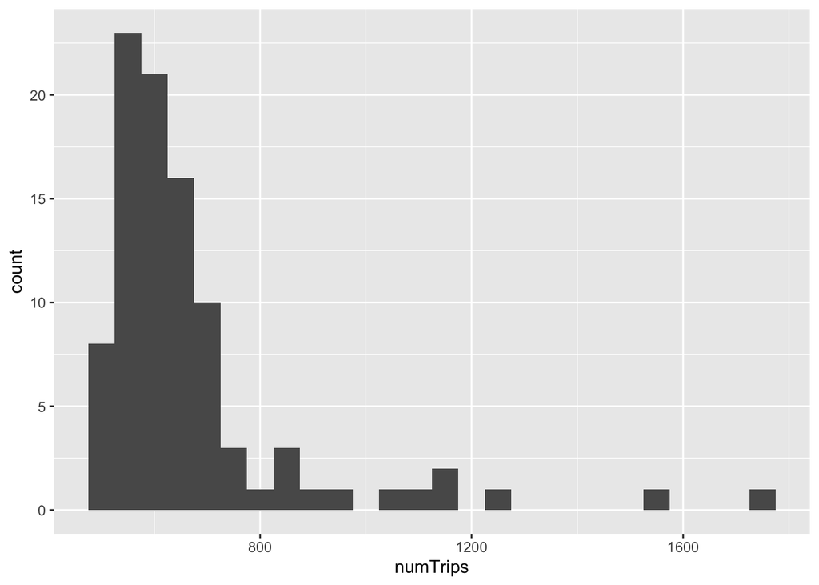

```r
routes %>%
  ggplot(aes(numTrips)) + geom_histogram(binwidth =50)
```

## Linear Model To Predict Popularity

```r
s2 <- sample %>%
  left_join(( routes %>% select(-numTrips)) ,by=c("route"="route")) %>%
  na.omit()
```

```r
model <- lm(routePopScore ~ poverty_prop + white_prop +total_pop + not_us_citizen_prop + borough + tripduration + median_income, data=s2 )
summary(model)
```

```
##
## Call:
## lm(formula = routePopScore ~ poverty_prop + white_prop + total_pop +
##     not_us_citizen_prop + borough + tripduration + median_income,
##     data = s2)
##
## Residuals:
##      Min       1Q   Median       3Q      Max
## -2.12476 -0.08842 -0.04417  0.02982  0.48405
##
## Coefficients:
##                       Estimate Std. Error t value Pr(>|t|)
## (Intercept)          1.348e-01  5.909e-03  22.813   <2e-16 ***
## poverty_prop        -6.480e-01  1.622e-02 -39.937   <2e-16 ***
## white_prop           5.097e-02  5.943e-03   8.577   <2e-16 ***
## total_pop           -1.296e-05  2.451e-07 -52.888   <2e-16 ***
## not_us_citizen_prop  3.049e-01  1.205e-02  25.309   <2e-16 ***
## boroughManhattan     1.147e-01  2.316e-03  49.508   <2e-16 ***
## tripduration         1.239e-06  7.872e-08  15.746   <2e-16 ***
## median_income       -4.390e-07  1.701e-08 -25.804   <2e-16 ***
## ---
## Signif. codes:  0 '***' 0.001 '**' 0.01 '*' 0.05 '.' 0.1 ' ' 1
##
## Residual standard error: 0.1485 on 63119 degrees of freedom
## Multiple R-squared:  0.1286, Adjusted R-squared:  0.1285
## F-statistic:  1330 on 7 and 63119 DF,  p-value: < 2.2e-16
```

## Conclusion

There is much more information that can be gleamed from the given data sets. Based on data that was obtained from the US census data set, one can get an idea of the demographics of the area’s that the stations are located in. Based on this we can see if any of this data is correlated to the popularity of routes that start at a particular station. I would also like to see how weather impacts the use of the program,compare to taxi/lyft data , safety data / traffic patterens, etc.

## References

datHere. 2020. https://data.beta.nyc/en/dataset/pediacities-nyc-neighborhoods/resource/7caac650-d082-4aea-9f9b-3681d568e8a5.

Lakshmanan, Valliappa. 2016. “Repeatable Sampling of Data Sets in BigQuery for Machine Learning.” *O’Reilly Media*. O’Reilly Media, Inc. https://www.oreilly.com/content/repeatable-sampling-of-data-sets-in-bigquery-for-machine-learning/.

Motivate International, Inc. n.d. “Citi Bike System Data.” *Citi Bike NYC*. https://www.citibikenyc.com/system-data.

Petti, Bill. 2020. “Leveraging US Census Data in BigQuery.” *Root Mean Squared Musings*. https://billpetti.github.io/2020-10-19-using-bigquery-to-join-census-location-data-geocoding-sql/.